# Statistical inference with the GSS data

## Introduction

### Summary

In this document the author presents an exploratory analysis & statistical inference based on the publicly available dataset provided by General Social Survey ([GSS](http://gss.norc.org/)).

### About the General Social Survey (GSS)

[Here](http://gss.norc.org/) is a excerpt from GSS webpage: “*The General Social Survey - Since 1972, the General Social Survey (GSS) has provided politicians, policymakers, and scholars with a clear and unbiased perspective on what Americans think and feel about such issues as national spending priorities, crime and punishment, intergroup relations, and confidence in institutions.*”

### About GSS dataset

Generally speaking, the GSS datasets are publicly available, and can be found in [here](http://gss.norc.org/get-the-data). As provided in the project description, the GSS is a survey using USA citizens, whose *“[…] questions cover a diverse range of issues including national spending priorities, marijuana use, crime and punishment, race relations, quality of life, confidence in institutions, and sexual behavior.”*.

Regarding the codebook, you can find it [here](http://gss.norc.org/get-documentation).

Note that this analysis was done in the context of Duke MOOC course in Coursera (introduction inferential statistics), so the dataset was provided with some slight modifications with R in mind as mentioned: *“Unlike the full General Social Survey Cumulative File, we have removed missing values from the responses and created factor variables when appropriate to facilitate analysis using R.”*

#### Data Citation

Smith, Tom W., Michael Hout, and Peter V. Marsden. General Social Survey, 1972-2012 [Cumulative File]. ICPSR34802-v1. Storrs, CT: Roper Center for Public Opinion Research, University of Connecticut /Ann Arbor, MI: Inter-university Consortium for Political and Social Research [distributors], 2013-09-11. doi:10.3886/ICPSR34802.v1

Persistent URL: http://doi.org/10.3886/ICPSR34802.v1

## Reproduceability - local setup

### Load packages

```r
library(ggplot2)
library(dplyr)
library(statsr)
```

### Load data

Locally on my machine I have put the data in a folder in the same directory as this Rmd file. Thus, to reproduce this project, setwd() where this script is and run the following snippet to load the data.

```r
script.dir = getwd()
data.dir = paste(sep="/", script.dir, "data")
data.file = paste(sep="/", data.dir, "gss.Rdata")
load(data.file)
```

This will store in your global environment dataframe called “gss”.

The dataset contains a relatively extensive amount of variables (114), and observations (57061):

```r
dim(gss)
```

```
## [1] 57061   114
```

To get more meta info about the dataset:

```r
str(gss)
```

```
## 'data.frame':    57061 obs. of  114 variables:
##  $ caseid  : int  1 2 3 4 5 6 7 8 9 10 ...
##  $ year    : int  1972 1972 1972 1972 1972 1972 1972 1972 1972 1972 ...
##  $ age     : int  23 70 48 27 61 26 28 27 21 30 ...
##  $ sex     : Factor w/ 2 levels "Male","Female": 2 1 2 2 2 1 1 1 2 2 ...
##  $ race    : Factor w/ 3 levels "White","Black",..: 1 1 1 1 1 1 1 1 2 2 ...
##  $ hispanic: Factor w/ 28 levels "Not Hispanic",..: NA NA NA NA NA NA NA NA NA NA ...
##  $ uscitzn : Factor w/ 4 levels "A U.S. Citizen",..: NA NA NA NA NA NA NA NA NA NA ...
##  $ educ    : int  16 10 12 17 12 14 13 16 12 12 ...
##  $ paeduc  : int  10 8 8 16 8 18 16 16 12 10 ...
##  $ maeduc  : int  NA 8 8 12 8 19 12 14 12 7 ...
##  $ speduc  : int  NA 12 11 20 12 NA NA NA NA 11 ...
##  $ degree  : Factor w/ 5 levels "Lt High School",..: 4 1 2 4 2 2 2 4 2 2 ...
##  $ vetyears: Factor w/ 5 levels "None","Less Than 2 Yrs",..: NA NA NA NA NA NA NA NA NA NA ...
##  $ sei     : num  NA NA NA NA NA NA NA NA NA NA ...
```

[output cut: 86 more lines]

Another useful overview of the data is using the summary function. As one can see next, there is a considerable number of variables which have NA’s as value

```r
summary(gss)
```

```
##      caseid           year           age           sex
##  Min.   :    1   Min.   :1972   Min.   :18.0   Male  :25146
##  1st Qu.:14266   1st Qu.:1983   1st Qu.:31.0   Female:31915
##  Median :28531   Median :1993   Median :43.0
##  Mean   :28531   Mean   :1992   Mean   :45.7
##  3rd Qu.:42796   3rd Qu.:2002   3rd Qu.:59.0
##  Max.   :57061   Max.   :2012   Max.   :89.0
##                                 NA's   :202
##     race                                       hispanic
##  White:46350   Not Hispanic                        :16936
##  Black: 7926   Mexican, Mexican American, Chicano/A: 1204
##  Other: 2785   Puerto Rican                        :  258
##                Spanish                             :   83
##                Cuban                               :   77
##                (Other)                             :  362
##                NA's                                :38141
##                                                                                              uscitzn
##  A U.S. Citizen                                                                                  :  375
##  Not A U.S. Citizen                                                                              :  378
##  A U.S. Citizen Born In Puerto Rico, The U.S. Virgin Islands, Or The Northern Marianas Islands   :    6
##  Born Outside Of The United States To Parents Who Were U.S Citizens At That Time (If Volunteered):   11
##  NA's                                                                                            :56291
##
##
##       educ           paeduc          maeduc          speduc
##  Min.   : 0.00   Min.   : 0.00   Min.   : 0.00   Min.   : 0.00
##  1st Qu.:12.00   1st Qu.: 8.00   1st Qu.: 8.00   1st Qu.:12.00
##  Median :12.00   Median :12.00   Median :12.00   Median :12.00
##  Mean   :12.75   Mean   :10.55   Mean   :10.71   Mean   :12.78
##  3rd Qu.:15.00   3rd Qu.:13.00   3rd Qu.:12.00   3rd Qu.:15.00
##  Max.   :20.00   Max.   :20.00   Max.   :20.00   Max.   :20.00
##  NA's   :164     NA's   :16888   NA's   :10132   NA's   :27435
##             degree                  vetyears          sei
##  Lt High School:11822   None            :18093   Min.   :17.10
##  High School   :29287   Less Than 2 Yrs :  816   1st Qu.:32.40
##  Junior College: 3070   2 To 4 Years    : 2123   Median :39.00
##  Bachelor      : 8002   More Than 4 Yrs :  847   Mean   :48.42
##  Graduate      : 3870   Some,Dk How Long:    5   3rd Qu.:63.50
##  NA's          : 1010   NA's            :35177   Max.   :97.20
##                                                  NA's   :25784
```

[output cut: 233 more lines]

```
##  Govt Action       : 4806   Govt Do More      : 4061
##  Agree With Both   :12273   Agree With Both   :10874
##  People Help Selves: 3087   Govt Does Too Much: 4137
##  NA's              :36895   NA's              :37989
##
##
##
##                helpsick                     helpblk
##  Govt Should Help  : 8241   Govt Help Blks      : 2688
##  Agree With Both   : 8903   Agree With Both     : 8540
##  People Help Selves: 2183   No Special Treatment: 8656
##  NA's              :37734   NA's                :37177
##
##
##
```

OK, enough “cosmetic” analysis, let us dive into our research.

## Part 1: About Data collection

Prior to analysing the data, it is essencial that one investigates how the sample data was collected, in order to know its limitations and potential in terms of inference. Namely, we want to know if it is generalizable and if we can prove causality.

The type of this study is “observational”, as oposed to “experimental”, since it consists of survey collection.

As one can infer from [in the section “How you were selected”](http://gss.norc.org/For-Survey-Participants), researchers cluster areas which they believe represent a cross-section of the populaiton, and then random sample a given sample size from those clusters.

Moreover, the sample consists of US citizens who actually volunteerly answer to the questions in the survey. Since the data collected depends on voluntary response, there might be an inherent bias involved. For example, some individuals who suffer from a given desease/health condition might be more reluctant to participate in such a survey.

Even though not so relevant for analyzing if one can make causal inference based on this study, it is important to note that interviewees do not to answer all questions for the survey to be considered complete, as mentioned [in the section “What if I do not want to answer a question?”](http://gss.norc.org/For-Survey-Participants) .

Nonetheless, it is assumed that the sample is representative of the population at hand, given its large sample size (57061 observations) and randomness.

```r
dim(gss)[1]
```

```
## [1] 57061
```

#### Conclusion

We can thus conclude that since this is an observational study which used random sampling, researchers can at best **generalize conclusions**, although **not prove causality**. This is due to the fact that no random assignment was used while conducting the study.

## Part 2: Research question

In this research, we are generally interested in finding more about how someone’s generation can influence its opinion regarding current controversial questions. More specifically about their opinion regarding homosexual relationships. Before we properly formulate our research question, some additional steps need to be performed in order to clean the data to minimize potential effect of confounding variables.

To assure that no historical occurrences in distinct years influence our outcome, we segment our data to a single snapshot of time, namely of isolating the year of 2012 (last year present in the provided dataset).

```r
gss12 = subset(gss, year>="2012")
n = dim(gss12)[1]
n
```

```
## [1] 1974
```

Finally, we need to group respondats by generation according to birth year.

| Year born | Age range | Generation |
| --- | --- | --- |
| 1946 - 1964 | 66 - 48 | Baby Boomers (BB) |
| 1965 - 1979 | 47 - 33 | Generation X (GX) |
| 1980 - 1994 | 32 - 18 | Generation Y (GY) |
| 1995 - 2010 | 17 - 2 | Generation Z (GZ) |

This information was based on [this](http://mccrindle.com.au/resources/Generations-Defined-Sociologically.pdf) table.

Given the fact that the minimum age that is present in the GSS questionaire is 18 and that the age refers to the year 2012, Genaration Z must be excluded from the current study. Let us create a new variable - regular categorical with 3 levels - which categorizes respondants into their correspondent generation.

```r
gss12$generation = as.factor(ifelse((gss12$age > 17) & (gss12$age < 33), "GY", ifelse((gss12$age >= 33) & (gss12$age <= 47), "GX", "BB")))
table(gss12$generation)
```

```
##
##  BB  GX  GY
## 973 536 460
```

We thus formulate our research question in the following manner:

### Research Question

**Research quesion:** Is there a relationship between the generation to which someone belongs and their opinion regarding the topic homosexual relationships related?

- Explanatory variable: “generation” (according to the table provided previously); variable type: regular categorical, 3 levels (“BB”, “GX”, “GY”);
- Response variable: “homosex” (Opinion about Homosexual sex relations); variable type: categorical ordinal with 4 levels (“Always Wrong”, “Almst Always Wrg”, “Sometimes Wrong”, “ot Wrong At All”)

Note: the level “other” was not considered, as it has no respondant using it, and logically does not contribute to this study.

## Part 3: Exploratory data analysis

To recapitulate, our research question is if we can find convincing evidence that the generation which someone belongs to has an influence on homosexual relationships. Moreover, we filtered the “gss” dataset for the year 2012, and created a new categorical variable called “generation”.

Time to start taking care of this new dataset.

### NA’s

There are several approaches on can use to deal with NA’s, such as imputation or simple naive removal.

#### NA’s “homosex” var

Our subset contains several NA’s, more precisely 735.

```r
summary(gss12$homosex)
```

```
##     Always Wrong Almst Always Wrg  Sometimes Wrong Not Wrong At All
##              567               37               82              553
##            Other             NA's
##                0              735
```

Given that the “homosex”" is our response variable, the approach taken was to filter those NA’s.

```r
gss12 = subset(gss12, is.na(homosex) ==F)
# make sure subsetting is exactly 735 as we wanted:
n - dim(gss12)[1] # 735 - correct, we can update our sample size
```

```
## [1] 735
```

```r
n = dim(gss12)[1]
summary(gss12$homosex)
```

```
##     Always Wrong Almst Always Wrg  Sometimes Wrong Not Wrong At All
##              567               37               82              553
##            Other
##                0
```

#### NA’s “generation” var

There are only 5 NA’s values present in our generation variable, due to respondants who refused to declare their age.

```r
summary(gss12$generation)
```

```
##   BB   GX   GY NA's
##  612  331  291    5
```

```r
# confirm there was no mistake, and validate if age also has 5 NA's
summary(gss12$age) # confirmed
```

```
##    Min. 1st Qu.  Median    Mean 3rd Qu.    Max.    NA's
##      18      33      47      48      61      89       5
```

Given their scarse level, the simpler approach was to filter them

```r
gss12 = subset(gss12, is.na(generation) == F)
# confirm it is equal to 5
n - dim(gss12)[1] # correct
```

```
## [1] 5
```

```r
n = dim(gss12)[1] # update sample size
```

### Explore generation var

The first point that stands out is that there are considerably more respondants belonging to Baby Boomers generation, than to any other generation.

```r
summary(gss12$generation)
```

```
##  BB  GX  GY
## 612 331 291
```

The same conclusion becomes visually very apparent in the following illustration, which counts the respondants per age, coloring by generation:

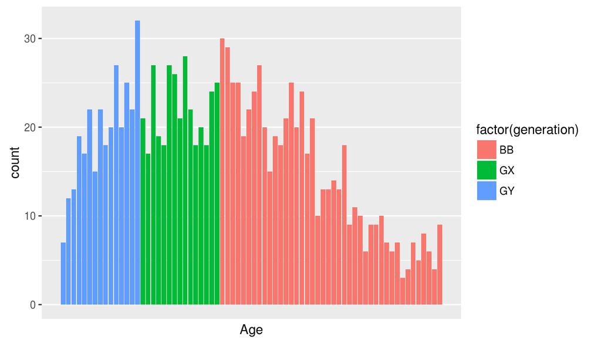

```r
ggplot(gss12, aes(x = age, fill = factor(generation))) +
  geom_bar(stat='count', position='dodge') +
  scale_x_continuous(breaks=c(1:5)) +
  labs(x = 'Age')
```

```r
summary(gss12$age)
```

```
##    Min. 1st Qu.  Median    Mean 3rd Qu.    Max.
##      18      33      47      48      61      89
```

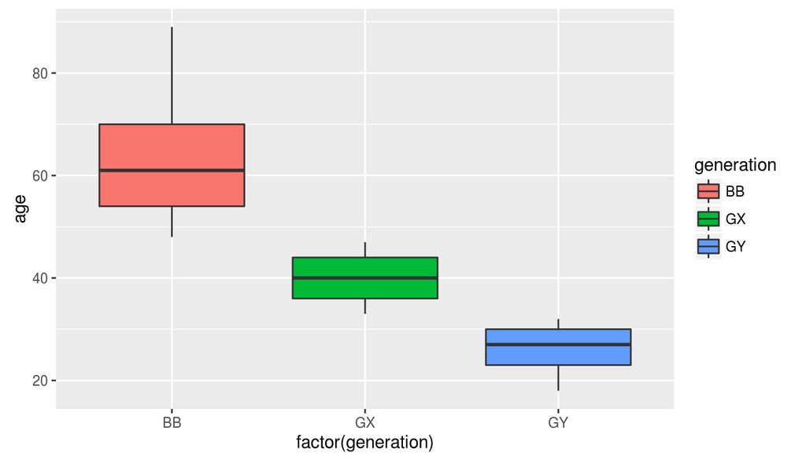

```r
ggplot(gss12, aes(x=factor(generation), y=age, fill=generation)) + geom_boxplot()
```

### Explore homosex var

We can see that opinions on homosexual sex are considerably polarized: in the majority of times either they consider “always wrong”, or “Not wrong at all”:

```r
table(gss12$homosex)
```

```
##
##     Always Wrong Almst Always Wrg  Sometimes Wrong Not Wrong At All
##              565               37               82              550
##            Other
##                0
```

To make our case more explicit, let us compute the percentage:

```r
prop.table(table(gss12$homosex))
```

```
##
##     Always Wrong Almst Always Wrg  Sometimes Wrong Not Wrong At All
##       0.45786062       0.02998379       0.06645057       0.44570502
##            Other
##       0.00000000
```

### Exploring variable association

As previously observed, we can see that among generations the majority of values are exactly on the polarized view - in the majority of times either they consider “always wrong”, or “Not wrong at all”:

```r
table(gss12$homosex, gss12$generation)
```

```
##
##                     BB  GX  GY
##   Always Wrong     340 135  90
##   Almst Always Wrg  17  13   7
##   Sometimes Wrong   37  20  25
##   Not Wrong At All 218 163 169
##   Other              0   0   0
```

The mosaic plot helps already illustrate visually how the number of people answering “Always Wrong” decreases from “BB” generation to “GY”, and number of people answring “not wrong at all” progressively increases from “BB” to “GY”.

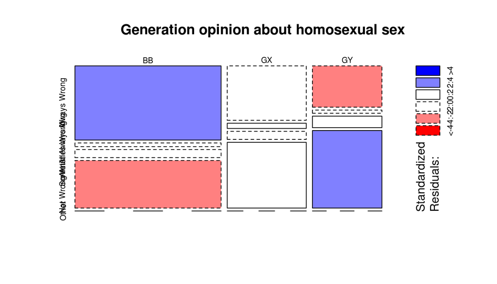

```r
mosaicplot(table(gss12$generation, gss12$homosex), main='Generation opinion about homosexual sex', shade=TRUE)
```

Moreover, looking at an equivalent plotting with a boxplot, the same potential trend is also apparent.

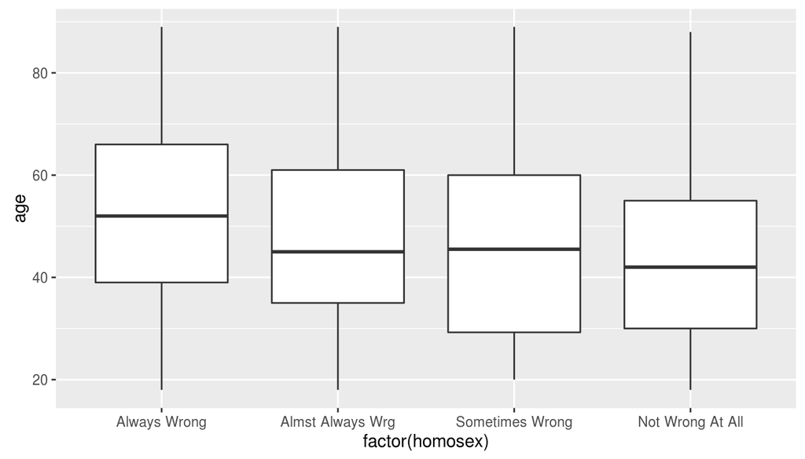

```r
ggplot(gss12, aes(x=factor(homosex), y=age)) + geom_boxplot()
```

The next boxplot gives more detailed insight, by comparing generation and age with opinion about homosexual sex.

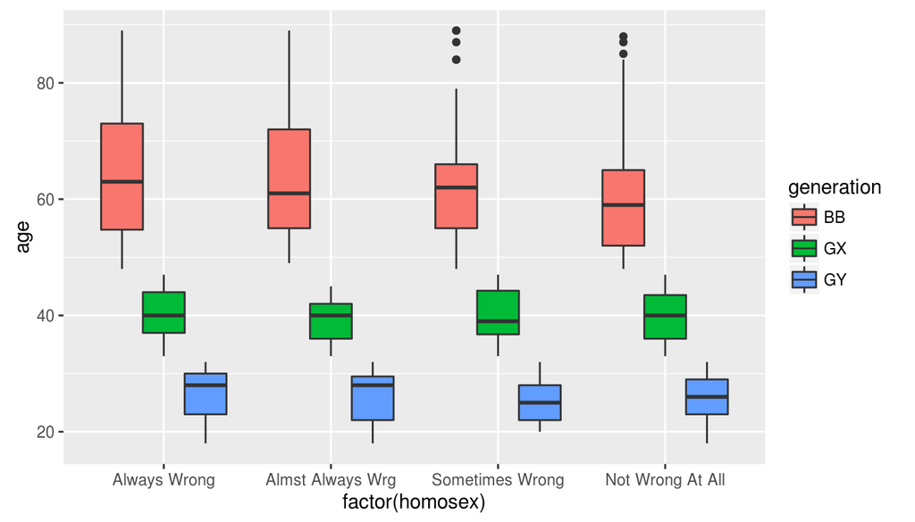

```r
ggplot(gss12, aes(x=factor(homosex), y=age, fill=generation)) + geom_boxplot()
```

## Part 4: Inference

Once again, we are interested in finding out if there is any evidence of a relationship between the generation someone belongs to, and their opinion on homosexual sex.

To perform our statistical analysis, we formulate this question as the following hypothesis:

1. $H_0$: (There is nothing going on, and) Generation and opinion about homosexual sex are **independent** (opinion does **not** vary by generation)
2. $H_A$: (There is something going on, and) Generation and opinion about homosexual sex are indeed **dependent** (opinion **does** vary by generation)

Since we are comparing two categorical variables, we use the Chi-Square independence test (for a 5% significance level). This test is suitable for this situation, since we are interested in comparing if the observed counts are statistically different from the expected counts. In this case, a large deviation between expected and observed would provide strong evidence that the alternative hypothesis is true, and that the two categorical variables are indeed dependent.

The conditions to apply the Chi-Square independence test are the following:

1. Independence: Sampled observations must be independent.

‣ random sample/assignment - condition meet, since respondants are randomly selected as previously explained

‣ if sampling without replacement, n < 10% of population - our n is defineitely smaller than 10% of the population.

```r
n
```

```
## [1] 1234
```

‣ each case only contributes to one cell in the table - condition satisfied

2. Sample size: Each particular scenario (i.e. cell) must have at least 5 expected cases - the minimum level is 7, which means condition is satisfied

```r
table(gss12$homosex, gss12$generation)
```

```
##
##                     BB  GX  GY
##   Always Wrong     340 135  90
##   Almst Always Wrg  17  13   7
##   Sometimes Wrong   37  20  25
##   Not Wrong At All 218 163 169
##   Other              0   0   0
```

Note: as previously mentioned, we are not considering the level “Other”.

Thus, we conclude that all conditions are satified, and we can proceed and apply Chi Square test of independence.

```r
table(gss12$homosex, gss12$generation)
```

```
##
##                     BB  GX  GY
##   Always Wrong     340 135  90
##   Almst Always Wrg  17  13   7
##   Sometimes Wrong   37  20  25
##   Not Wrong At All 218 163 169
##   Other              0   0   0
```

```r
prob_always_wrong = (340 + 135 + 90)/n
prob_almost_always_wrong = (17 + 13 +  7)/n
prob_sometimes_wrong = (37 + 20 + 25)/n
prob_not_wrong = (218 + 163 + 169)/n
# confirm adds up to 100% / 1
prob_always_wrong + prob_almost_always_wrong + prob_sometimes_wrong +prob_not_wrong
```

```
## [1] 1
```

Lets calculate the expected proportions:

```r
table(gss12$generation)
```

```
##
##  BB  GX  GY
## 612 331 291
```

```r
obs_total_bb = table(gss12$generation)[1]
obs_total_gx = table(gss12$generation)[2]
obs_total_gy = table(gss12$generation)[3]

# BB
exp_prob_always_wrong_bb = prob_always_wrong* obs_total_bb
exp_prob_almost_always_wrong_bb = prob_almost_always_wrong* obs_total_bb
exp_prob_sometimes_wrong_bb = prob_sometimes_wrong* obs_total_bb
exp_prob_not_wrong_bb = prob_not_wrong* obs_total_bb
# GX
exp_prob_always_wrong_gx = prob_always_wrong* obs_total_gx
exp_prob_almost_always_wrong_gx = prob_almost_always_wrong* obs_total_gx
exp_prob_sometimes_wrong_gx = prob_sometimes_wrong* obs_total_gx
exp_prob_not_wrong_gx = prob_not_wrong* obs_total_gx
#GY
exp_prob_always_wrong_gy = prob_always_wrong* obs_total_gy
exp_prob_almost_always_wrong_gy = prob_almost_always_wrong* obs_total_gy
exp_prob_sometimes_wrong_gy = prob_sometimes_wrong* obs_total_gy
exp_prob_not_wrong_gy = prob_not_wrong* obs_total_gy
```

Appologies in advance for the super boring calculations. Please bear with me just a little longer, so that we can calculate the test statistic.

```r
chi_square_bb = ((340 - exp_prob_always_wrong_bb)**2)/exp_prob_always_wrong_bb + ((17 -exp_prob_almost_always_wrong_bb)**2)/exp_prob_almost_always_wrong_bb + ((37 - exp_prob_sometimes_wrong_bb)**2)/exp_prob_sometimes_wrong_bb + ((218 - exp_prob_not_wrong_bb)**2)/exp_prob_not_wrong_bb

chi_square_gx = ((135 - exp_prob_always_wrong_gx)**2)/exp_prob_always_wrong_gx + ((13 -exp_prob_almost_always_wrong_gx)**2)/exp_prob_almost_always_wrong_gx + ((20 - exp_prob_sometimes_wrong_gx)**2)/exp_prob_sometimes_wrong_gx + ((163 - exp_prob_not_wrong_gx)**2)/exp_prob_not_wrong_gx

chi_square_gy = ((90 - exp_prob_always_wrong_gy)**2)/exp_prob_always_wrong_gy + ((7 -exp_prob_almost_always_wrong_gy)**2)/exp_prob_almost_always_wrong_gy + ((25 - exp_prob_sometimes_wrong_gy)**2)/exp_prob_sometimes_wrong_gy + ((169 - exp_prob_not_wrong_gy)**2)/exp_prob_not_wrong_gy
```

OK, we are almost in business.

```r
chi_square = chi_square_bb + chi_square_gx + chi_square_gy
df = (3-1)*(3-1)
```

So after all this (extremely boring) calculations, we can finally compute our test statistic for a 5% significance level:

```r
t_statistic = pchisq(chi_square, df=df, lower.tail = F)
```